# Lecture 2: Basic Computation and Stats

Kelly

### And how will all of this help me?

You might be asking yourself: “I very rarely care to add vectors together or to create variables or to do any of the things that **R** seems to be able to do. Why might I care?”

To which we respond: you will be surprised. You plot things all the time, right? (If not, you should!) You often have questions like “Yes, I know that 5 seaplanes leave Lake Union normally, but yesterday there were 9. That seems like a lot… is it really a lot? Or might that just happen by chance?” Or perhaps “I talked to 10 people at the Council meeting, and 3 were in favor of the proposal. Is that more than I expected, given the polling numbers?” **R** is your tool for these kinds of things. And for plotting… perhaps you want to plot the number of planes that take off each day of the month from Lake Union, and then you want to do that for each month of the year. Easy in **R**, hard in Excel.

And all kinds of other fun stuff you haven’t even thought about yet.

### So, to review:

**R** is a language, rather than a particular product. As a result, it can be confusing when people talk about how they work in with **R**. You can write in any language using a plain text editor (such as Notepad++, Atom, BBedit, Textwrangler, or just the plain old notepad that came by default on your computer). But the text editor couldn’t *run* the code… for that, you would need a program that speaks and executes the **R** language. And wouldn’t it be easier if you could write code, run that code, and visualize the code more easily? I thought so. That’s why people use **R**-specific software to do it. That software comes in a few flavors:

- Command-line **R** can be run on a terminal (command-prompt) with plain text. For super-nerds.
- For the less-nerdy, the GUI (Graphical User Interface… i.e., where you can use a mouse and click on things) version of **R** is available on [CRAN](https://cran.r-project.org/) (CRAN stands for the Comprehensive R Archive Network, which is also where most contributed packages live). This is a big improvement for most people, but has in part been superseded by…
- RStudio, which is an *Integrated Development Environment* (IDE), the idea of which is to keep everything all in one place: you can write code, run code, see plots, see what files are where, see what objects you’ve got loaded into an environment, etc… all on one screen. That’s why we’re using RStudio.

But the point is that **R** is the language, and RStudio (or whatever you might otherwise choose… there are other options) is the environment in which you’re using **R**.

#### Some Vocabulary of Note:

- *Rmarkdown* is a handy way of keeping code and plots and calculations and text and notes all in one place. The document you are reading now is written in Rmarkdown, and you’ll write your problem sets, etc, the same way. The details don’t matter, but just know that Rstudio is the way that you easily create Rmarkdown documents. You can find the basics of Rmarkdown [here](https://rmarkdown.rstudio.com/authoring_basics.html) or in the cheatsheets provided in the files associated with our class. (Rmarkdown is itself a kind of [mini-language for formatting text](https://en.wikipedia.org/wiki/Markdown). Note that the tab character, and new lines, are important in *Rmarkdown* for formatting, in a way that they are generally ignored in the *R* language, so be careful.)
- The *console* is where the action takes place in RStudio. If you run code from the *source* window (which is your writing/editing space), you see the code being carried out in the *console*.
- Just so you know, you can create freestanding bits of code (*scripts*) that you can call from the command line, when you’re more advanced. You run them like programs (which they are), without having to edit anything in Rstudio, etc.

### Packages : Extensions for **R**

You already installed and loaded a package in **R** last week. But let’s take a minute to see what that’s all about. The *Pirate’s Guide* says:

> When you download and install R for the first time, you are installing the Base R software. Base R will contain most of the functions you’ll use on a daily basis like `mean()` and `hist()`. However, only functions written by the original authors of the R language will appear here. If you want to access data and code written by other people, you’ll need to install it as a *package*. An R package is simply a bunch of data, from functions, to help menus, to vignettes (examples), stored in one neat package.

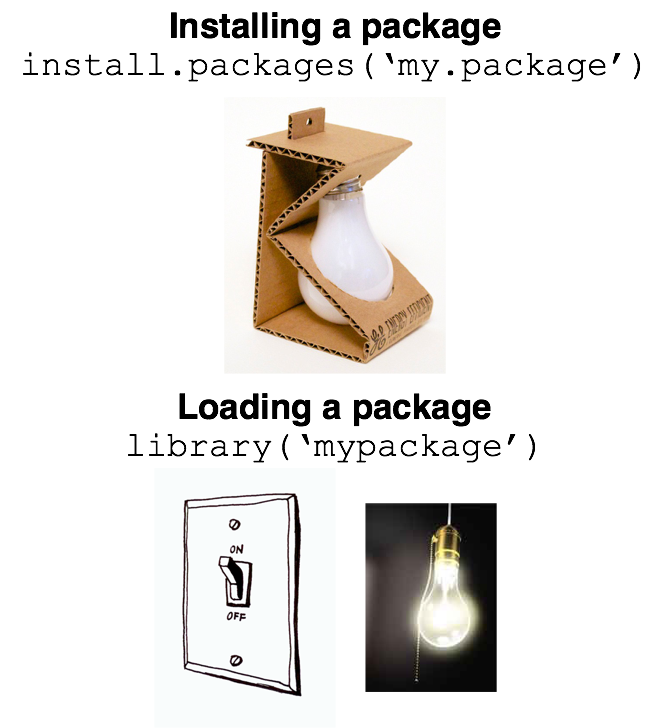

An R package is like a lightbulb. First you need to order it with install.packages(). Then, every time you want to use it, you need to turn it on with library()

> A package is like a light bulb. In order to use it, you first need to order it to your house (i.e.; your computer) by *installing* it. Once you’ve installed a package, you never need to install it again. However, every time you want to actually use the package, you need to turn it on by *loading* it. Here’s how to do it.

### Installing a new package

> Installing a package simply means downloading the package code onto your personal computer. There are two main ways to install new packages. The first, and most common, method is to download them from the Comprehensive R Archive Network (CRAN). CRAN is the central repository for R packages. To install a new R package from CRAN, you can simply run the code `install.packages("name")`, where “name” is the name of the package. For example, to download the `yarrr` package, which contains several data sets and functions we will use in this book, you should run the following:

[figure not shown]

CRAN (Comprehensive R Archive Network) is the main source of R packages

```r
# Install the yarrr package from CRAN
#   You only need to install a package once!
install.packages("yarrr")
```

> When you run `install.packages("name")` R will download the package from CRAN. If everything works, you should see some information about where the package is being downloaded from, in addition to a progress bar.

[figure not shown]

> Like ordering a light bulb, once you’ve installed a package on your computer you never need to install it again (unless you want to try to install a new version of the package). However, every time you want to use it, you need to turn it on by loading it.

### Loading a package

> Once you’ve installed a package, it’s on your computer. However, just because it’s on your computer doesn’t mean R is ready to use it. If you want to use something, like a function or dataset, from a package you *always* need to *load* the package in your R session first. Just like a light bulb, you need to turn it on to use it!

> To load a package, you use the `library()` function. For example, now that we’ve installed the `yarrr` package, we can load it with `library("yarrr")`:

```r
# Load the yarrr package so I can use it!
#   You have to load a package in every new R session!
library("yarrr")
```